# Where and when would a food delivery app display their ad on a famous tv series website?

# *PROGRAM EVALUATION: Do millennial Binge watchers order food online?*

### What is the fuss all about?

This idea began when I was binge watching a South Indian Web Series on a famous website. For every few minutes there was an ad being displayed of a food delivery app. What struck me is how were they deciding of the ad is being displayed to the right audience? Please pay attention to the questions below. What other questions can you think of?

- What if the ads are being displayed to people who do not eat outside food? Isnt it waste of investment on ads?
- Do people who watch series for a long duration click on the ad and order food? (Binge Watchers) In other words, is there a correlation between bingewatching and ordering food online?(One of those millennial bad habits)
- What browser are viewers using? Is it also related to the above question by any chance?
- What month would displaying the ad be most effective? Example: Summer and Winter vacations are the time millinnials snuggle to binge watch and order food online.
- Based on this information, the website owners can charge different amounts to advertisers? An amazing strategy to get sponsors too.

Imagine there is a desert delivery app entering the market and wants to target millinnials. Especially couch potatoes.(Ouch!) So, they decide to sponsor a webseries and approach a famous company currently hosting an Indian TV Series who are currently looking for sponsors.

### The manager of the delivery app has to decide if they should place their ad and sponsor this TV series.

Because of their cost restrictions, the company can only afford to sponsor in one location in India, and they want to take maximum benefit.

[figure not shown]

The manager has the following datasets for about 90k users:

- users.csv - Information about users registered in 2015 & 2016, in different cities.
- engagement.csv - Which browser and how many hours per week is each user watching the series. And, also if the user is binge watching or drip watching
- behavior.csv - Whether the user clicks on the ad and if the user is ordering food.

Note: We are assuming that the user_id is same on the food delivery app and the tv series website. (Would be realistic if it was email id, but for convenience we use numbers.

We are going to help the manager by predicting the following:

#### 1. In which city he should place his ad?

#### 2. We check if people are watching the tv series for a long duration, do they click? Do they order food? If this is true, should the manager increase the frequency of ads as the number of hours per week user watches increases?

#### 3. Which season/month is best to place the ad?

#### 4. Is there any other factor affecting the correlation between clicking on ads, and ordering/not ordering food? Example: Browser?

### Let's get to code already!

```python
#importing necessary libraries.
import pandas as pd
import numpy as np
from matplotlib import pyplot as plt
%matplotlib inline

import seaborn as sns
from functools import reduce

import warnings
warnings.filterwarnings('ignore')
```

```python
#Reading the datasets

df_users = pd.read_csv('dataset/users.csv')
df_behavior = pd.read_csv('dataset/behavior.csv')
df_eng = pd.read_csv('dataset/engagement.csv')
```

```python
#We split the date. Since there are only two years, 2015 & 2016 we work only on the MONTH to make this simple.
df_users['registration'] = pd.to_datetime(df_users['registration'])
df_users['year'], df_users['month'] = df_users['registration'].dt.year, df_users['registration'].dt.month
#Users dataset
df_users.head()
```

|  | user_id | registration | city | year | month |
| --- | --- | --- | --- | --- | --- |
| 0 | 90482091 | 2015-01-11 | Hyderabad | 2015 | 1 |
| 1 | 41529564 | 2015-01-11 | Hyderabad | 2015 | 1 |
| 2 | 47570654 | 2015-01-11 | Hyderabad | 2015 | 1 |
| 3 | 96119909 | 2015-10-31 | Hyderabad | 2015 | 10 |
| 4 | 57248612 | 2015-10-29 | Bengaluru | 2015 | 10 |

```python
df_users.shape
```

```
(88874, 5)
```

```python
df_users.isnull().sum()
```

```
user_id         0
registration    0
city            0
year            0
month           0
dtype: int64
```

```python
#user behavior dataset sample values
df_behavior.head()
```

|  | user_id | click_ad | order_food |
| --- | --- | --- | --- |
| 0 | 90482091 | 0 | 0 |
| 1 | 41529564 | 0 | 0 |
| 2 | 47570654 | 0 | 0 |
| 3 | 96119909 | 0 | 0 |
| 4 | 57248612 | 0 | 0 |

```python
df_behavior.shape
```

```
(88874, 3)
```

```python
df_behavior.isnull().sum()
```

```
user_id       0
click_ad      0
order_food    0
dtype: int64
```

```python
# Convert the viewing hours per week into 6 bins and take it into a new data frame.
bin = [-1,3,6,9,12,15,18]
category = pd.cut(df_eng.hrs_per_week,bin)
category = category.to_frame()
category.columns = ['viewing_range']
df_engagement = pd.concat([df_eng,category],axis = 1)
df_engagement.head()
```

|  | user_id | browser | viewer_type | hrs_per_week | viewing_range |
| --- | --- | --- | --- | --- | --- |
| 0 | 769245 | IE | binge | 4.91 | (3, 6] |
| 1 | 21650570 | Safari | binge | 3.97 | (3, 6] |
| 2 | 91760162 | Chrome | drip | 3.55 | (3, 6] |
| 3 | 90748752 | Chrome | drip | 5.46 | (3, 6] |
| 4 | 66876824 | Chrome | binge | 3.87 | (3, 6] |

```python
df_eng.shape
```

```
(88874, 4)
```

```python
df_engagement.isnull().sum()
```

```
user_id          0
browser          0
viewer_type      0
hrs_per_week     0
viewing_range    0
dtype: int64
```

## Part 1: Single Dimension Plots

```python
# convenience function to plot the count of the viewers by differnt parameters

def count_plot_cf(count_by, data_frame):
    #ax = sns.countplot(x = count_by,data = data_frame)
    ax = sns.countplot(data_frame[count_by],
                 order = data_frame[count_by].value_counts().index)
    for p, label in zip(ax.patches, data_frame[count_by].value_counts()):
        ax.annotate(label,(p.get_x()+0.25, p.get_height()+0.45))

    plt.suptitle("Count of viewers as sorted by {}".format(count_by).capitalize())
    plt.show()
```

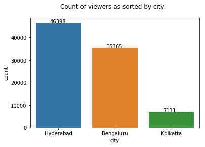

```python
count_plot_cf('city',df_users)
```

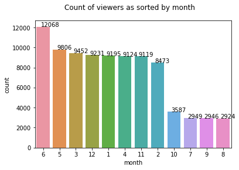

```python
#since there are only two years, 2015 & 2016, we will skip it and consider month wise combined in 2 years.
count_plot_cf('month',df_users)
```

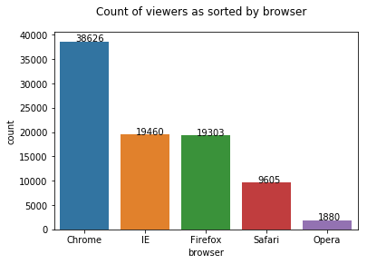

```python
count_plot_cf('browser',df_eng)
```

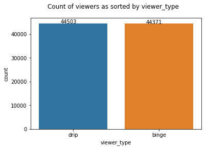

```python
count_plot_cf('viewer_type',df_eng)
```

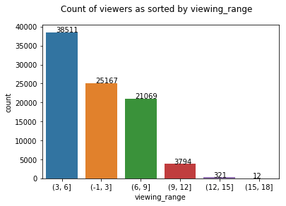

```python
count_plot_cf('viewing_range',df_engagement)
```

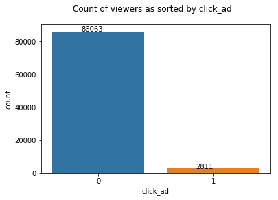

```python
count_plot_cf('click_ad',df_behavior)
```

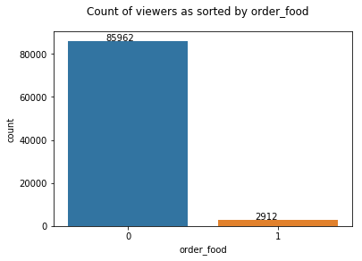

```python
count_plot_cf('order_food',df_behavior)
```

```python
round(df_behavior['order_food'].mean()*100,2)
```

```
3.28
```

```python
round(df_behavior['click_ad'].mean()*100,2)
```

```
3.16
```

### Observations till now based only single dimension

1. Number of viewers is more in Hyderabad than in any other city.
2. Views are maximum in June followed by almost same viewership in May, Mar, Dec, Jan, Apr, Nov. Views is least in August.
3. People use Chrome the maximum to watch TV series
4. Drip & Binge watching plot does not make sense at all since both are almost the same. We need other factors to decide anything about this.
5. Mean of tv series users ordering food is 3.28%. Means there is a potential scope for business.

However, these points independently may not mean anything.

## Part 2: Segmentation Plots

```python
def count_plot_cf(count_by, data_frame):
    plt.figure(figsize=(7,5))
    ax = sns.barplot(x= df_behavior['click_ad'], y = df_behavior['order_food'],hue = data_frame[count_by],data = df_behavior)

    plt.suptitle("Segmentation plot of ad clicking vs ordering food by {}".format(count_by).capitalize())
    plt.show()
```

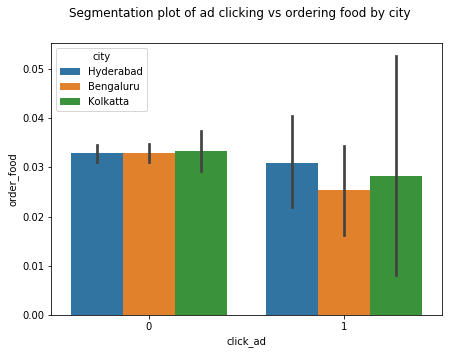

```python
count_plot_cf('city',df_users)
```

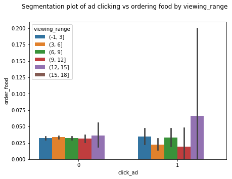

```python
count_plot_cf('viewing_range',df_engagement)
```

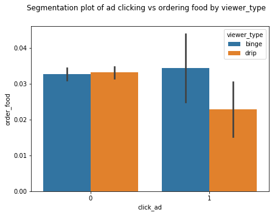

```python
count_plot_cf('viewer_type',df_engagement)
```

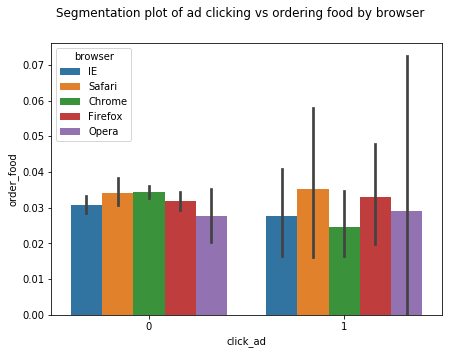

```python
count_plot_cf('browser',df_engagement)
```

### Observations

1. People using Chrome are ordering food, even if they are not clicking the ad
2. There seems to be no significant difference in number of people ordering the food based on click rate when they are binge watching. (So, should the manager simply stop focusing on whether he should target binge watchers and consider everyone the same? Not yet.)

## Part 3: Machine Learning

Spearman's Correlation is used to find if there is a relation between two variables. Although, visually we did see there was none. We are making sure here. Do look up what is Pearson's & Spearman's Correlation.

```python
ranked_data = df_behavior.rank()
spearman_corr = ranked_data.loc[:,["click_ad","order_food"]].corr(method= "pearson")
print("Spearman's correlation: ")
print(spearman_corr)
```

```
Spearman's correlation:
            click_ad  order_food
click_ad    1.000000   -0.004371
order_food -0.004371    1.000000
```

Since it is negative, we can safely say that clicking on ad & ordering food are not realted to each other. There is another factor which is influencing these two. We also find the covariance(as seen below it is running in negative direction) between these two to prove the same.

```python
np.cov(df_behavior['click_ad'],df_behavior['order_food'])
print("Covariance between radius mean and area mean: ",df_behavior['click_ad'].cov(df_behavior['order_food']))
```

```
Covariance between radius mean and area mean:  -0.00013619195238583968
```

Note: This is a classic real life scenario. Since, I did not manipulate the dataset although I built it, it blew.

There are other factors which motivate viewers to click ads and order food.

### We will use a simple Random Forest Classification algorithm to predict if he should place the ad on the TV Series, based on the parameters: month, clicking on ad, browser, viewer type, viewing hours.

```python
#Merging our dataframes to create a new dataframe ready for RF Classification
dfs = [df_users, df_behavior, df_engagement]
df_final = reduce(lambda left,right: pd.merge(left,right,on='user_id'), dfs)
df = df_final.drop(['registration', 'year','hrs_per_week','user_id'], axis=1)
df.head()
```

|  | city | month | click_ad | order_food | browser | viewer_type | viewing_range |
| --- | --- | --- | --- | --- | --- | --- | --- |
| 0 | Hyderabad | 1 | 0 | 0 | Chrome | drip | (6, 9] |
| 1 | Hyderabad | 1 | 0 | 0 | Safari | drip | (3, 6] |
| 2 | Hyderabad | 1 | 0 | 0 | Opera | binge | (3, 6] |
| 3 | Hyderabad | 10 | 0 | 0 | Firefox | drip | (9, 12] |
| 4 | Bengaluru | 10 | 0 | 0 | IE | binge | (-1, 3] |

```python
from sklearn.model_selection import train_test_split

from sklearn.ensemble import GradientBoostingClassifier, partial_dependence
from sklearn.metrics import roc_auc_score
```

```python
#Building Analytical base table to melt the data frame.
abt = pd.get_dummies(df)
abt.head()
```

|  | month | click_ad | order_food | city_Bengaluru | city_Hyderabad | city_Kolkatta | browser_Chrome | browser_Firefox | browser_IE | browser_Opera | browser_Safari | viewer_type_binge | viewer_type_drip | viewing_range_(-1, 3] | viewing_range_(3, 6] | viewing_range_(6, 9] | viewing_range_(9, 12] | viewing_range_(12, 15] | viewing_range_(15, 18] |
| --- | --- | --- | --- | --- | --- | --- | --- | --- | --- | --- | --- | --- | --- | --- | --- | --- | --- | --- | --- |
| 0 | 1 | 0 | 0 | 0 | 1 | 0 | 1 | 0 | 0 | 0 | 0 | 0 | 1 | 0 | 0 | 1 | 0 | 0 | 0 |
| 1 | 1 | 0 | 0 | 0 | 1 | 0 | 0 | 0 | 0 | 0 | 1 | 0 | 1 | 0 | 1 | 0 | 0 | 0 | 0 |
| 2 | 1 | 0 | 0 | 0 | 1 | 0 | 0 | 0 | 0 | 1 | 0 | 1 | 0 | 0 | 1 | 0 | 0 | 0 | 0 |
| 3 | 10 | 0 | 0 | 0 | 1 | 0 | 0 | 1 | 0 | 0 | 0 | 0 | 1 | 0 | 0 | 0 | 1 | 0 | 0 |
| 4 | 10 | 0 | 0 | 1 | 0 | 0 | 0 | 0 | 1 | 0 | 0 | 1 | 0 | 1 | 0 | 0 | 0 | 0 | 0 |

```python
#Seperating the target variable & input features.
y = abt.order_food
X = abt.drop('order_food',axis=1)
```

```python
#Splitting into training & test sets
X_train,X_test,y_train,y_test = train_test_split(X,y,test_size=0.1,random_state=123)
```

```python
from sklearn.ensemble import RandomForestClassifier
regressor1 = RandomForestClassifier(n_estimators=200, random_state=0)
regressor1.fit(X_train, y_train)
y_pred = regressor1.predict(X_test)
```

```python
print(confusion_matrix(y_test,y_pred))
print(classification_report(y_test,y_pred))
print(accuracy_score(y_test, y_pred))
```

```
[[8599    0]
 [ 289    0]]
              precision    recall  f1-score   support

           0       0.97      1.00      0.98      8599
           1       0.00      0.00      0.00       289

   micro avg       0.97      0.97      0.97      8888
   macro avg       0.48      0.50      0.49      8888
weighted avg       0.94      0.97      0.95      8888

0.9674842484248425
```

```python
pred = regressor1.predict_proba(X_test)
pred = [p[1] for p in pred]

roc_auc_score(y_test,pred)
```

```
0.4996410623106976
```

Why it is still okay to have a low AUROC and good accuracy score: Check out these links:

- https://stackoverflow.com/questions/47104129/getting-a-low-roc-auc-score-but-a-high-accuracy
- https://stats.stackexchange.com/questions/308513/roc-auc-is-higher-than-accuracy-score-what-does-this-mean

*What it essentially means is: We need not care about low AUROC when we are able to get good accuracy value. Because AUROC you get (something like) the accuracy averaged across all possible thresholds and what this classifier does in a purely theoretical and abstract situation when averaged across all possible thresholds should pose very little interest for a practitioner. What is of real importance is confusion matrix, precision, recall, fscore & accuracy.*

Next we calculate the feature importances from our model which gives us a basic idea on what to consider and what not to.

```python
feature_importances = pd.DataFrame(regressor1.feature_importances_,
                                   index = X_train.columns,
                                    columns=['importance']).sort_values('importance',ascending=False)
feature_importances
```

|  | importance |
| --- | --- |
| month | 0.620693 |
| click_ad | 0.062680 |
| browser_Firefox | 0.027271 |
| city_Bengaluru | 0.026680 |
| city_Hyderabad | 0.026057 |
| viewing_range_(3, 6] | 0.024349 |
| viewing_range_(-1, 3] | 0.023977 |
| browser_IE | 0.022693 |
| browser_Chrome | 0.022692 |
| viewing_range_(6, 9] | 0.022224 |
| city_Kolkatta | 0.022057 |
| browser_Safari | 0.022033 |
| viewer_type_binge | 0.017581 |
| viewer_type_drip | 0.016992 |
| viewing_range_(9, 12] | 0.016465 |
| browser_Opera | 0.012208 |
| viewing_range_(12, 15] | 0.010913 |
| viewing_range_(15, 18] | 0.002434 |

### Business Conclusions:

Again, these still cannot be concluded. The Manager could run a sample program with a focus group using these results for a few days before investing.